# SMS Spam Collection Dataset

A dataset of 5572 text messages, to be classified as spam or ham (i.e. not spam).

See: https://www.kaggle.com/datasets/uciml/sms-spam-collection-dataset/data

Our approach is to implement a Naive Bayes classifier, using the training set to estimate the a priori probability of a text being spam or ham, as well as the probability of particular words being in spam/ham texts. From there, Bayesian probability gives us the probability of a message being spam or not.

### Imports

```python
import pandas as pd
import numpy as np
import collections
import re
import sklearn.model_selection
import sklearn.metrics
from nltk.stem import PorterStemmer
import matplotlib.pyplot as plt
```

### Read the dataset and do some preprocessing

```python
df = pd.read_csv("spam.csv", encoding="latin1")
```

```python
df.rename(columns=dict(v1="spam", v2="text"),
          inplace=True)
df = df.loc[:, ~df.columns.str.contains('^Unnamed')]
df.spam = (df.spam == "spam").astype(np.uint)

def preprocess_text(text):
    return text.lower()

df.text = df.text.apply(preprocess_text)
```

```python
for i, row in df.sample(n=10).iterrows():
    print(i, row.spam, row.text)
    print("======")
```

```
1284 0 but if she.s drinkin i'm ok.
======
787 1 ever thought about living a good life with a perfect partner? just txt back name and age to join the mobile community. (100p/sms)
======
1035 0 hello baby, did you get back to your mom's ? are you setting up the computer now ? filling your belly ? how goes it loverboy ? i miss you already ... *sighs*
======
2090 0 s:-)kallis wont play in first two odi:-)
======
4531 0 ok both our days. so what are you making for dinner tonite? am i invited?
======
4338 0 just got outta class gonna go gym.
======
1913 0 you want to go?
======
5468 1 urgent! last weekend's draw shows that you have won å£1000 cash or a spanish holiday! call now 09050000332 to claim. t&c: rstm, sw7 3ss. 150ppm
======
4196 1 free for 1st week! no1 nokia tone 4 ur mob every week just txt nokia to 8007 get txting and tell ur mates www.getzed.co.uk pobox 36504 w45wq norm150p/tone 16+
======
3277 0 what happened in interview?
======
```

### Split into train/test sets.

75% train, 25% test.

```python
X_train, X_test, y_train, y_test = sklearn.model_selection.train_test_split(
    df.drop(["spam"], axis=1),
    df.drop(["text"], axis=1))
N_train, N_test = len(X_train), len(X_test)
print(N_train, N_test, N_train/(N_train+N_test))
```

```
4179 1393 0.75
```

### Feature selection and extraction.

We use one type of feature only: boolean values representing whether particular strings are in the text. All of the following substrings correspond to a single boolean feature:

- Any word in the training set that appears in more than 1 text. "Words" must start and end with an alphabetical character - this includes "I", "I'm", "u", "l8er", etc. They are converted to lower case and stemmed to reduce duplicates.
- 1-digit numbers, 2-to-3-digit numbers, 4-to-7-digit numbers, and 8+-digit numbers.
- A few different currency symbols fall under the "money" feature.

```python
PS = PorterStemmer()
REG = re.compile("([a-zA-Z]+.*[a-zA-Z])|[a-zA-Z]")
def extract_words(text):
    for chunk in text.split(" "):
        m = REG.match(chunk)
        if m:
            yield PS.stem(m.group())
print([w for w in extract_words("blah!  $1000 i'm i clams    favorite")])
```

```
['blah', "i'm", 'i', 'clam', 'favorit']
```

```python
wordcounts = collections.defaultdict(int)
for text in X_train["text"]:
    words_in_this = set()
    for w in extract_words(text):
        words_in_this.add(w)
    for w in words_in_this:
        wordcounts[w] += 1
```

```python
final_words = sorted([(w, c) for (w, c) in wordcounts.items() if c > 1],
                     key=lambda wc: wc[1],
                     reverse=True)
print(len(final_words))
print(final_words[:10])
print(final_words[-10:])
```

```
2801
[('to', 1264), ('i', 1222), ('you', 1126), ('a', 859), ('the', 756), ('u', 609), ('and', 606), ('in', 602), ('is', 542), ('me', 515)]
[('www.smsco.net', 2), ('now.i', 2), ('whatsup', 2), ('fujitsu', 2), ('underwear', 2), ('juli', 2), ('race', 2), ('rice', 2), ('ericsson', 2), ('smart', 2)]
```

```python
final_words = set([w for w, _ in final_words])
```

This class abstracts over which feature gets mapped to which index in the features vector. Every feature has a label; for words we can use the word itself, and we can give special names to non-words.

```python
class FeatureMap:
    def __init__(self):
        self._i = 0
        self._label_to_index = {}
        self._index_to_label = {}

    def add_feature(self, label):
        self._label_to_index[label] = self._i
        self._index_to_label[self._i] = label
        self._i += 1

    def init_features(self, dtype=None):
        return np.zeros(self._i, **{} if dtype is None else dict(dtype=dtype))

    def set_feature(self, features, label, value):
        features[self._label_to_index[label]] = value

    def num_features(self):
        return self._i

    def get_label(self, index):
        return self._index_to_label[index]

    def get_index(self, label):
        return self._label_to_index[label]
```

Actually computing the feature vector.

```python
NUMREG = re.compile("[0-9]+")
NUM_RANGES = [1, 2, 4, 8]
MONEY_SYMBOLS = ["$", "€", "£", "¥"]
MONEY_LABEL = "%money"

def make_feature_map(wordlist, num_labels):
    fm = FeatureMap()
    for word in wordlist:
        fm.add_feature(word)
    for label in num_labels:
        fm.add_feature(label)
    fm.add_feature(MONEY_LABEL)
    return fm

def make_num_labels(num_ranges):
    return [f"%num{n}" for n in num_ranges]

def make_extract_features(wordlist, num_ranges):
    num_labels = make_num_labels(num_ranges)
    fm = make_feature_map(wordlist, num_labels)
    def extract_features(text):
        f = fm.init_features()
        for w in extract_words(text):
            if w in wordlist:
                fm.set_feature(f, w, 1)
        for n in NUMREG.findall(text):
            for lower_bound, label in zip(reversed(num_ranges), reversed(num_labels)):
                if len(n) >= lower_bound:
                    fm.set_feature(f, label, 1)
                    break
        for c in text:
            if c in MONEY_SYMBOLS:
                fm.set_feature(f, MONEY_LABEL, 1)
                break
        return f
    return extract_features
```

Testing out the feature extraction...

```python
ef = make_extract_features(["blah", "i", "go", "beer", "call"], NUM_RANGES)
print(ef("i am going to call you at 10399 $"))
```

```
[0. 1. 1. 0. 1. 0. 0. 1. 0. 1.]
```

### Naive Bayes implementation.

Here's the math. If `y` is the label (1 if spam and 0 if not) and `x` is the vector of features, then the probability of something being spam is

```
P(y=1|x) = P(x,y=1)/P(x)
         = P(y=1)P(x|y=1)/(P(y=1)P(x|y=1) + P(y=0)P(x|y=0))
```

`P(y)` can be estimated by the proportion of spam in the training set.

Note that `P(x|y=1) ~= \prod_{i=1}^D P(x_i|y=1)`, where `D` is the number of features. For each word `i`, `P(x_i|y=1)` can be estimated as the rate of occurrence of that word in the spam class.

Laplace smoothing is used in the estimate of `P(x_i|y=1)`, which is:

```
(#TimesWordOccurs+1)/(#Texts+2)
```

The +1 ensures that, if `#TimesWordOccurs` is 0, the probability of occurrence isn't 0 (the word could just be v rare). Similarly, if a word occurs in every single text, the +2 ensures that the probability isn't 1.

```python
def calc_p_x_and_y(X, P_y, P_x_given_y):
    p = np.repeat(P_y, len(X))
    # There should be a way to vectorise this.
    for i, row in enumerate(X):
        p[i] *= np.prod(P_x_given_y[row]) * np.prod(1-P_x_given_y[~row])
    return p

class NaiveBayes:
    """Expects input arrays to have elements of type np.bool."""
    def __init__(self):
        self.P_y1 = None
        self.P_x_given_y0 = None
        self.P_x_given_y1 = None

    def fit(self, X, y):
        N = len(y)
        y1s = np.sum(y)
        self.P_y1 = y1s/N
        self.P_x_given_y0 = (np.sum(X[~y,:], axis=0)+1) / (N-y1s+2)
        self.P_x_given_y1 = (np.sum(X[y,:], axis=0)+1) / (y1s+2)

    def predict(self, X, raw_prob=False, debug=False):
        P_x_and_y0 = calc_p_x_and_y(X, 1-self.P_y1, self.P_x_given_y0)
        P_x_and_y1 = calc_p_x_and_y(X, self.P_y1, self.P_x_given_y1)
        P_y1_given_x = P_x_and_y1/(P_x_and_y1 + P_x_and_y0)
        if debug:
            print(P_x_and_y0)
            print(P_x_and_y1)
        return P_y1_given_x if raw_prob else (P_y1_given_x > .5).astype(np.ubyte)
```

Testing out on a sample case. I manually verified the results. It's not the ideal test case because the a priori probabilities are equal.

```python
X = np.array([[1, 0, 1, 0],
              [0, 1, 1, 0],
              [0, 1, 1, 0],
              [1, 1, 1, 1]],
             dtype=np.bool)
y = np.array([1, 0, 1, 0], dtype=np.bool)

nb = NaiveBayes()
nb.fit(X, y)
print("--- parameters")
print(nb.P_y1)
print(nb.P_x_given_y0)
print(nb.P_x_given_y1)

print("--- prediction")
print(nb.predict(np.array([[1, 1, 1, 0],
                           [1, 0, 1, 0]],
                          dtype=np.bool),
                 raw_prob=True))
```

```
--- parameters
0.5
[0.5  0.75 0.75 0.5 ]
[0.5  0.5  0.75 0.25]
--- prediction
[0.5  0.75]
```

### Bringing it all together and evaluating on the test set.

```python
ef = make_extract_features(final_words, NUM_RANGES)
def df_extract_features(df, ef):
    return np.array([
        ef(row.text) for _, row in df.iterrows()
    ], dtype=np.bool)

def to_model_format(X, y, ef):
    return df_extract_features(X, ef), np.array(y.spam, dtype=np.bool)
```

```python
m_X_train, m_y_train = to_model_format(X_train, y_train, ef)
m_X_test, m_y_test = to_model_format(X_test, y_test, ef)
```

```python
model = NaiveBayes()
model.fit(m_X_train, m_y_train)
```

```python
pred_train = model.predict(m_X_train)
```

```python
def calc_accuracy_percentage(pred, y):
    return 100*np.sum(pred==y)/len(y)
```

```python
print("Training set accuracy percentage:", round(calc_accuracy_percentage(pred_train, m_y_train), 3))
```

```
Training set accuracy percentage: 99.067
```

```python
pred_test = model.predict(m_X_test)
print("Test set accuracy percentage:", round(calc_accuracy_percentage(pred_test, m_y_test), 3))
```

```
Test set accuracy percentage: 98.923
```

Success! An accuracy of almost 99% on the test set.

### Analysis of results.

A priori, about 13.5% of the texts are spam. Declaring everything to be not-spam would give us 86.5% accuracy, so we're doing better than that, but maybe not as good as it might appear at first sight.

```python
model.P_y1
```

```
0.13591768365637713
```

Precision (fraction of texts classified as spam that are actually spam), recall (accuracy at identifying spam), and confusion matrix.

13 spam texts are incorrectly classified as ham, 2 ham texts are incorrectly classified as spam.

```python
print("Recall:", sklearn.metrics.recall_score(m_y_test, pred_test))
print("Precision:", sklearn.metrics.precision_score(m_y_test, pred_test))
print("Confusion matrix:")
print(sklearn.metrics.confusion_matrix(m_y_test, pred_test))
```

```
Recall: 0.9273743016759777
Precision: 0.9880952380952381
Confusion matrix:
[[1212    2]
 [  13  166]]
```

Taking a look at the misclassified texts. One of the false positives (incorrectly-classified ham) is a chain text (thanks to ChatGPT for helping me to remember that term) and could arguably be considered spam. The other is tricky because it has characteristics of spam, e.g. the word "contact".

On the false negative side, i.e. undetected spam, some of them have mispellings that probably help to evade detection ("wining") - we could use basic spelling correction to counter this. Some of the spam has URLs / other types of links, it would be helpful to have a feature for that. One of them splits up the phone number - "0800 505060" - which then doesn't trigger our "8+-digit" feature.

Retroactively going back and improving the feature selection would possibly lead to overfitting on this dataset. If we had been more careful, we could've tried our model on a subset of the texts to figure out what sort of spam evades detection, leading to improved feature engineering. Although, the dataset may not be large enough for that.

```python
mask = (m_y_test != pred_test)
incorrect = X_test[mask].join(y_test[mask])
for _, row in incorrect.iterrows():
    print("spam:" if row.spam == 1 else "ham:", row.text)
```

```
spam: bloomberg -message center +447797706009 why wait? apply for your future http://careers. bloomberg.com
spam: sorry i missed your call let's talk when you have the time. i'm on 07090201529
spam: how come it takes so little time for a child who is afraid of the dark to become a teenager who wants to stay out all night?
spam: money i have won wining number 946 wot do i do next
spam: hello darling how are you today? i would love to have a chat, why dont you tell me what you look like and what you are in to sexy?
spam: reminder: you have not downloaded the content you have already paid for. goto http://doit. mymoby. tv/ to collect your content.
ham: we have sent jd for customer service cum accounts executive to ur mail id, for details contact us
spam: do you ever notice that when you're driving, anyone going slower than you is an idiot and everyone driving faster than you is a maniac?
spam: email alertfrom: jeri stewartsize: 2kbsubject: low-cost prescripiton drvgsto listen to email call 123
spam: interflora - åòit's not too late to order interflora flowers for christmas call 0800 505060 to place your order before midnight tomorrow.
spam: filthy stories and girls waiting for your
ham: plz note: if anyone calling from a mobile co. &amp; asks u to type # &lt;#&gt;  or # &lt;#&gt; . do not do so. disconnect the call,coz it iz an attempt of 'terrorist' to make use of the sim card no. itz confirmd by nokia n motorola n has been verified by cnn ibn.
spam: check out choose your babe videos @ sms.shsex.netun fgkslpopw fgkslpo
spam: not heard from u4 a while. call me now am here all night with just my knickers on. make me beg for it like u did last time 01223585236 xx luv nikiyu4.net
spam: your credits have been topped up for http://www.bubbletext.com your renewal pin is tgxxrz
```

Seeing the prediction for texts that consist of a single word. This can tell us which are the "most spammy" words, according to the model.

```python
feature_map = make_feature_map(final_words, make_num_labels(NUM_RANGES))
X_one_only = np.eye(feature_map.num_features(), dtype=np.bool)
pred_one_only = model.predict(X_one_only, raw_prob=True)
word_pred_pairs = [(feature_map.get_label(i), p)
                   for i, p in enumerate(pred_one_only)]
word_pred_pairs.sort(key=lambda pair: pair[1], reverse=True)
print("Most spammy features:")
for label, p in word_pred_pairs[:20]:
    print("  ", label, p)
print("Least spammy features:")
for label, p in word_pred_pairs[-10:]:
    print("  ", label, p)
```

```
Most spammy features:
   %num8 4.849944998306583e-05
   claim 2.1551104205454864e-05
   %num4 2.1359130935198095e-05
   prize 1.5827663335078766e-05
   won 1.208368150055925e-05
   award 1.0286417904084979e-05
   tone 9.031665881670267e-06
   guarante 9.031665881670262e-06
   voucher 6.831659735162032e-06
   t&c 6.352690324168992e-06
   pobox 5.170588351753613e-06
   %num2 5.1376721899143955e-06
   rington 4.703775728428128e-06
   bonu 4.703775728428107e-06
   %money 4.5865934436622556e-06
   weekli 4.471642379852343e-06
   mob 4.009898550877469e-06
   unsubscrib 4.009898550877443e-06
   valid 3.780278947337647e-06
   poli 3.7802789473376362e-06
Least spammy features:
   happi 3.317933789215728e-09
   she 3.2659681445431903e-09
   alreadi 3.21557721637072e-09
   too 2.7846021725829294e-09
   da 2.4834266711742456e-09
   say 2.264651635389679e-09
   later 2.101937702462825e-09
   he 2.038973503715481e-09
   lor 1.8703193998888758e-09
   i'll 1.7267543362561323e-09
```

To explain the strangely low probabilities for single-word texts, we look at `P(0^D|y)`, where we have `D` features and `0^D` is the all-zero vector. This shows us that spam messages are unlikely to have no known words, perhaps because they tend to be longer. A clever spammer could maybe craft a short spam text and it would be harder to detect.

```python
print(np.prod(1-model.P_x_given_y0))
print(np.prod(1-model.P_x_given_y1))
```

```
2.5492878988569676e-06
5.517622638497361e-13
```

Confirming this hunch -- spam messages are longer and tend to have more features present.

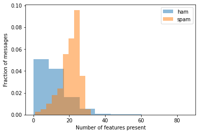

```python
plt.hist(np.sum(m_X_train[~m_y_train], axis=1),
         label="ham",
         alpha=.5,
         density=True)
plt.hist(np.sum(m_X_train[m_y_train], axis=1),
         label="spam",
         alpha=.5,
         density=True)
plt.legend()
plt.xlabel("Number of features present")
plt.ylabel("Fraction of messages")
```

So, how can a spammer circumvent the filter? Use a thesaurus to avoid spam-indicative words, and try to use words that are NOT spam indicative. Use misspellings: "cal1", "s3x", "one hundred" instead of "100". And short messages!

```python
for _, row in X_test[pred_test == m_y_test].join(y_test[pred_test == m_y_test]) \
        .sample(n=10) \
        .iterrows():
    print(row.spam, row.text)
```

```
0 thanks chikku..:-) gud nyt:-*
0 eh u send wrongly lar...
0 what time is ur flight tmr?
0 that way transport is less problematic than on sat night. by the way, if u want to ask  n  to join my bday, feel free. but need to know definite nos as booking on fri.
1 tbs/persolvo. been chasing us since sept forå£38 definitely not paying now thanks to your information. we will ignore them. kath. manchester.
1 sms auction - a brand new nokia 7250 is up 4 auction today! auction is free 2 join & take part! txt nokia to 86021 now!
1 ur ringtone service has changed! 25 free credits! go to club4mobiles.com to choose content now! stop? txt club stop to 87070. 150p/wk club4 po box1146 mk45 2wt
0 wow. you're right! i didn't mean to do that. i guess once i gave up on boston men and changed my search location to nyc, something changed. cuz on my signin page it still says boston.
1 update_now - 12mths half price orange line rental: 400mins...call mobileupd8 on 08000839402 or call2optout=j5q
0 ill be at yours in about 3 mins but look out for me
```

```python
def classify_text(model, extract_features_fn, text):
    return model.predict(extract_features_fn(text)[np.newaxis,:].astype(np.bool))[0]
TESTS = [
    # Some I made up to avoid spammy features.
    "c4ll one eight eight nine five seven for s3x",
    "help me, I'm in danger! call 12345678",
    # Trying to modify this spam message to bypass the filter, but it was hard! Had
    # to remove the number and "win", basically. Adding ham-indicative words didn't seem
    # to balance out spam-indicative words.
    "sunshine quiz wkly q! get a sony dvd player if u know which country liverpool played in mid week? ansr to eight-two-two-seven-seven. i'll say he later i'm happy to see you",
    # It's annoyingly easy to circumvent the filter by adding extra characters between letters or switching
    # out characters for, e.g., numbers. To be more resilient we'd have to account for that.
    "s.ms auction - a fresh nokia 7-2-5-0 is up 4 au-ction today! au-ction is gratis 2 join & take part! t3xt nokia to 8-6-0-2-1 now!"
]
for text in TESTS:
    print("spam" if classify_text(model, ef, text) == 1 else "ham", "-", text)
```

```
ham - c4ll one eight eight nine five seven for s3x
ham - help me, I'm in danger! call 12345678
ham - sunshine quiz wkly q! get a sony dvd player if u know which country liverpool played in mid week? ansr to eight-two-two-seven-seven. i'll say he later i'm happy to see you
ham - s.ms auction - a fresh nokia 7-2-5-0 is up 4 au-ction today! au-ction is gratis 2 join & take part! t3xt nokia to 8-6-0-2-1 now!
```

### Future work.

- The a priori probability can be weighted to tweak the balance between precision & recall.
- A Markov model could be used to estimate `P(x|y)` for spam and non-spam texts.
- It would be interesting to use a neural net model like BERT as a base to give text embeddings, then add an extra layer to give the spam/ham prediction. During training, only the weights of the final layer would be updated.